# Einblick in das Rechnen mit *agla*

von Holger Böttcher - hbomat@posteo.de  
Diese Arbeit steht unter der freien Lizenz [CC BY-SA 4.0](https://creativecommons.org/licenses/by-sa/4.0/deed.de)

### Abitur Bayern 2019

### Geometrie Teil B, Aufgabengruppe 2

Quelle: [serlo.org](https://de.serlo.org/mathe/deutschland/bayern/gymnasium/abiturpr%C3%BCfungen-l%C3%B6sung/mathematik-abitur-bayern-2019/geometrie,-teil-b,-aufgabengruppe-2)

*Die Variablen $x_1, x_2, x_3$ sind mit $x, y, z$ bezeichnet*

Die Abbildung zeigt den Würfel $ABCDEFGH$ mit $A\,(0\, |\, 0\, |\, 0)$ und $G\,(5\, |\, 5\, |\, 5)$ in einem  
kartesischen Koordinatensystem. Die Ebene $T$ schneidet die Kanten des Würfels unter  
anderem in den Punkten $I\,(5 \,|\, 0\, |\,1),\: J\,(2\, |\, 5\, |\, 0) ,\: K\,0\, |\, 5\, |\, 2)$ und $L\,(1\,|\, 0\, |\, 5)$ .

[figure not shown]

**a)** Zeichnen Sie das Viereck $IJKL$ in die Abbildung ein und zeigen Sie, dass es sich
$\:\:\:\:$um ein Trapez handelt, bei dem zwei gegenüberliegende Seiten gleich lang sind.
**b)** Ermitteln Sie eine Gleichung der Ebene $T\,$ in Normalenform.
$\:\:\:\:$(zur Kontrolle: $\:T :\: 5x + 4y + 5z - 30 = 0$ )
Für $a \in \mathbb{R}^+$ ist die Gerade $\:g_a:\:\vec{x} = \left( \begin{matrix} 2,5 \\ 0 \\ 3,5 \\ \end{matrix} \right) + \lambda \,\left( \begin{matrix} 0 \\ -10 a \\ \frac{2}{a} \\ \end{matrix} \right)\:\:$ mit $\lambda \in \mathbb{R}$ gegeben
**c)** Bestimmen Sie den Wert von $a$, sodass die Gerade $g_a$ die Würfelfläche $CDHG$
$\:\:\:\:$in ihrem Mittelpunkt schneidet.
Für jedes $a \in \mathbb{R}^+$ liegt die Gerade $g_a$ in der Ebene $U$ mit der Gleichung $x = 2,5$.
**d)** Ein beliebiger Punkt $P\,(p_1\, |\, p_2 \,|\, p_3)$ des Raums wird an der Ebene $U$ gespiegelt.
$\:\:\:\:$Geben Sie die Koordinaten des Bildpunkts $P\,'$ in Abhängigkeit von $p_1, p_2$ und $p_3$
$\:\:\:\:$an.
**e)** Spiegelt man die Ebene $T$ an $U$, so erhält man die von $T$ verschiedene Ebene $T\,'$ .
$\:\:\:\:$Zeigen Sie, dass für einen bestimmten Wert von $a$ die Gerade $g_a$ in der Ebene $T$
$\:\:\:\:$liegt, und begründen Sie, dass diese Gerade $g_a$ die Schnittgerade von $T$ und $T\,'$
$\:\:\:\:$ist.
**f)** Die Spitze einer Pyramide mit der Grundfläche $IJKL$ liegt auf der Kante
$\:\:\:\:$$[FG]$. Untersuchen Sie, ob die Höhe dieser Pyramide $2$ betragen kann.

Die 3D-Abbildungen in der vorliegenden HTML-Datei sind Schnappschüsse der  
Darstellungen in agla

```python
%run agla/start
```

Erzeugung eines Würfels als Prisma

```python
Würfel = w = Prisma(Viereck(v(5, 0, 0), v(0, 5, 0)), 5)
```

Erzeugung der Eckpunkte entsprechend der Abbildung

```python
A, B, C, D = w.grund.punkte
```

```python
E, F, G, H = w.deck.punkte
```

```python
zeichne(w,              # Kontrollgrafik
        bez=[(A, 'A'),
             (B, 'B'),
             (C, 'C'),
             (D, 'D'),
             (E, 'E'),
             (F, 'F'),
             (G, 'G'),
             (H, 'H')],
        box=nein)
```

[figure not shown]

Mit etwas Python läßt sich viel Schreibarbeit sparen - die nächste Anweisung erzeugt  
die gleiche Grafik

```python
#zeichne(w,      # zur Ausführung entfernen
#         bez=[(eval(x), x) for x in list('ABCDEFGH')],
#         box=nein)
```

Die anderen vorgegebenen Punkte sind

```python
I = v(5, 0, 1); J = v(2, 5, 0); K = v(0, 5, 2); L = v(1, 0, 5)
I, J, K, L
```

$$\left ( \left(\begin{matrix}5\\0\\1\end{matrix}\right), \quad \left(\begin{matrix}2\\5\\0\end{matrix}\right), \quad \left(\begin{matrix}0\\5\\2\end{matrix}\right), \quad \left(\begin{matrix}1\\0\\5\end{matrix}\right)\right )$$

### a)

```python
IJKL = Viereck(I, J, K, L)
```

Nachweis, dass ein Trapez vorliegt

```python
IJKL.form
```

$$Trapez$$

```python
trapez = IJKL

trapez.längen
```

$$\left ( \sqrt{35}, \quad 2 \sqrt{2}, \quad \sqrt{35}, \quad 4 \sqrt{2}\right )$$

```python
trapez.winkel
```

$$\left ( 76.1697750503496, \quad 103.83022494965, \quad 103.83022494965, \quad 76.1697750503496\right )$$

Die 3D-Grafik

```python
zeichne(w,
        [trapez, rot, 2],
        box=nein)
```

[figure not shown]

läßt sich mittels einer speziellen Parallelprojektion namens *schrägbild* auch als  
Schrägbild in 2D darstellen

```python
w2 = w.bild(schrägbild).in_2d

trapez2 = trapez.bild(schrägbild).in_körper.in_2d
```

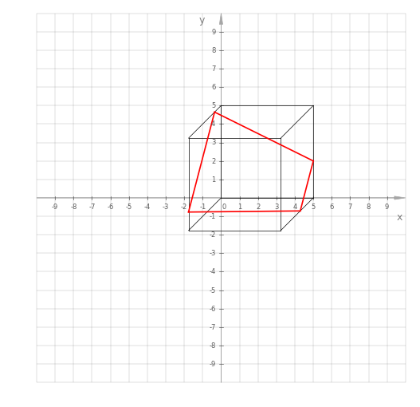

```python
zeichne(w2, [trapez2, rot, 2], gitter=ja)
```

### b)

Die Ebene $T$ wird über die drei Punkte $I, J, K$ mittels Stütz- und zwei Spannvektoren  
oder eleganter als Trägerebene für das Trapez erzeugt

```python
T = Ebene(I, v(I, J), v(I, K))
T.koord
```

$$5 x + 4 y + 5 z - 30=0$$

```python
T = trapez.ebene
T.koord
```

$$5 x + 4 y + 5 z - 30=0$$

### c)

```python
ga = Gerade(v(2.5, 0, 3.5), v(0, -10*a, 2/a), lamda)   # Schreibweise
ga.prg                                                 # lamda!
```

$$\left(\begin{matrix}x\\y\\z\end{matrix}\right)=\left(\begin{matrix}\frac{5}{2}\\0\\\frac{7}{2}\end{matrix}\right)+\lambda\,\left(\begin{matrix}0\\- 10 a\\\frac{2}{a}\end{matrix}\right)$$

Überprüfung der Aussage in der Aufgabenstellung, dass $g_a$ in $U$ liegt

```python
U = Ebene(1, 0, 0, -2.5)
U.koord
```

$$2 x - 5=0$$

```python
U.Koord(ga.pkt(t))
```

$$\text{die Gleichung ist erfüllt}$$

Der Mittelpunkt des Quadrates ist sein Schwerpunkt

```python
M = Viereck(C, D, H, G).schwer_pkt
M
```

$$\left(\begin{matrix}\frac{5}{2}\\5\\\frac{5}{2}\end{matrix}\right)$$

Die folgende Vektor-Gleichung ist zu lösen (linke Seite, rechte Seite wird als Nullvektor  
angenommen)

```python
gl = ga.pkt(lamda) - M  # Schreibweise lamda! (lambda ist in
gl                      # Python vergeben)
```

$$\left(\begin{matrix}0\\- 10 a \lambda - 5\\1 + \frac{2 \lambda}{a}\end{matrix}\right)$$

```python
löse(gl, [a, lamda])
```

$$\left [ \left \{ a : -1, \quad \lambda : \frac{1}{2}\right \}, \quad \left \{ a : 1, \quad \lambda : - \frac{1}{2}\right \}\right ]$$

Laut der Aufgabenstellung interessiert nur die positive Lösung für $a$, also $1$

Einsetzen des $\lambda$-Werte in die $pkt$-Methode des entsprechenden Scharelementes  
(Methode $sch\_el\,$) bestätigt die Richtigkeit der Rechnung

```python
ga.sch_el(1).pkt(-1/2)
```

$$\left(\begin{matrix}\frac{5}{2}\\5\\\frac{5}{2}\end{matrix}\right)$$

### d)

Für einen beliebigen Punkt der Form

```python
p1, p2, p3 = symbols('p_1, p_2, p_3')   # mehrstellige freie
                                        # Bezeichner (ohne Wert)
P = v(p1, p2, p3); P                    # müssen deklariert werden
```

$$\left(\begin{matrix}p_{1}\\p_{2}\\p_{3}\end{matrix}\right)$$

ist der an $U$ gespiegelte Punkt

```python
P.bild(spiegelung(U))   # Ergebnis zu d)
```

$$\left(\begin{matrix}- p_{1} + 5\\p_{2}\\p_{3}\end{matrix}\right)$$

Zur Erläuterung:

$spiegelung(U)$ (Spiegelung an der Ebene $U$) ist eine Abbildung mit einer  
Abbildungsmatrix und einem Verschiebungsvektor

```python
abb = spiegelung(U)
abb, abb.matrix, abb.versch
```

$$\left ( Abbildung, \quad \left(\begin{matrix}-1 & 0 & 0\\0 & 1 & 0\\0 & 0 & 1\end{matrix}\right), \quad \left(\begin{matrix}5\\0\\0\end{matrix}\right)\right )$$

Die Abbildungsgleichungen sind dieselben wie oben ablesbar (hier mit anderen  
Bezeichnungen für die Variablen)

```python
abb.gleich
```

$$\left ( x'=- x + 5, \quad y'=y, \quad z'=z\right )$$

### e)

```python
Ts = T.bild(spiegelung(U))    # Ts = T'
```

Einsetzen des allgemeinen Geradenpunktes in die Gleichung von $T$

```python
T.Koord(ga.pkt(t))
```

$$(t, a)\text{ ist Lösung der Gleichung}$$

$$- 40 a t + \frac{10 t}{a}= 0$$

führt auf eine Gleichung, die bei einem festen $a$-Wert für alle $t$ gelten soll

```python
gl1 = -40*a*t + 10*t/a
collect(gl1, t)         # SymPy-Anweisungen wurden nicht eingedeutscht
```

$$t \left(- 40 a + \frac{10}{a}\right)$$

Das ist nur möglich, wenn die Gleichung

```python
gl1.subs(t, 1)
```

$$- 40 a + \frac{10}{a}$$

erfüllt ist; in $\mathbb{R}^+$ ist das nur für $a=\dfrac{1}{2}$ der Fall, was den gesuchten $a$-Wert liefert:

```python
löse(gl1.subs(t, 1))
```

$$\left [ \left \{ a : - \frac{1}{2}\right \}, \quad \left \{ a : \frac{1}{2}\right \}\right ]$$

Mit der $sch\_el$ - Methode wird das entsprechende Scharelement der Geradenschar $g_a$  
ermittelt

```python
g1 = ga.sch_el(1/2)
g1.prg
```

$$\left(\begin{matrix}x\\y\\z\end{matrix}\right)=\left(\begin{matrix}\frac{5}{2}\\0\\\frac{7}{2}\end{matrix}\right)+\lambda\,\left(\begin{matrix}0\\-5\\4\end{matrix}\right)$$

Analog zu oben wird der allgemeine Punkt von $g_1$ in die Gleichung von $T'$ eingesetzt  
und gezeigt, dass die Gleichung für alle Werte von $t$ erfüllt ist, die Gerade $g_1$ also in  
der Ebene $T'$ liegt

```python
Ts.Koord(g1.pkt(t))
```

$$\text{die Gleichung ist erfüllt}$$

Da $g_1$ in beiden Ebenen liegt, ist sie die Schnittgerade von $T$ und $T'$

Die Kontrolle durch unmittelbare Anwendung der $schnitt$ - Methode

```python
T.schnitt(Ts).prg
```

$$\left(\begin{matrix}x\\y\\z\end{matrix}\right)=\left(\begin{matrix}\frac{5}{2}\\\frac{25}{6}\\\frac{1}{6}\end{matrix}\right)+s\,\left(\begin{matrix}0\\- \frac{10}{3}\\\frac{8}{3}\end{matrix}\right)$$

ergibt eine identische Gerade, die aber durch eine andere Gleichung beschrieben  
wird

```python
identisch(g1, T.schnitt(Ts))
```

```
True
```

### f)

Eine Zeichnung zur Erkundung der Lage ($T$ ist die Trägerebene für das Trapez und  
damit Grundfläche der Pyramide)

```python
zeichne(trapez, Strecke(F, G), T, F, G, achsen=nein, box=nein)
```

[figure not shown]

#### 1.Weg

Die Pyramidenhöhe ist der Abstand von der Grundfläche zur Spitze (ein Punkt der  
Strecke $[FG]$)

Für die beiden Endpunkte der Strecke gilt

```python
Abstand(T, F, d=5), Abstand(T, G, d=5)
```

$$\left ( 2.4618, \quad 4.9237\right )$$

Da die Werte für die anderen Streckenpunkte dazwischen liegen, kann $2$ nicht  
erreicht werden

#### 2. Weg

Die Grafik läßt vermuten, daß sich für irgendeinen Punkt der Geraden $FG$ ein  
Abstand von $2$ zur Ebene $T$ ergibt. Es wird gezeigt, dass es einen solchen Punkt gibt  
und dass er außerhalb der Strecke liegt

```python
g = Gerade(F, v(F, G))
gl = T.abstand(g.pkt(t)) - 2
L = löse(gl)
L
```

$$\left \{ t : -1 + \frac{\sqrt{66}}{10}\right \}$$

Der zum erhaltenen Parameterwert

```python
L[t].n()
```

$$-0.187596159536404$$

gehörende Geradenpunkt liegt nicht auf der Strecke $[FG]$, da bei der Erzeugung der  
Geraden $g$ der Punkt $F$ den Parameterwert $0$, $G$ den Parameterwert $1$ und alle  
anderen Punkte der Strecke Werte aus dem Intervall $(0, 1)$ erhalten haben

```python
g.pkt(0), F
```

$$\left ( \left(\begin{matrix}5\\0\\5\end{matrix}\right), \quad \left(\begin{matrix}5\\0\\5\end{matrix}\right)\right )$$

```python
g.pkt(1), G
```

$$\left ( \left(\begin{matrix}5\\5\\5\end{matrix}\right), \quad \left(\begin{matrix}5\\5\\5\end{matrix}\right)\right )$$

```python
g.pkt(1/2),  Strecke(F, G).mitte
```

$$\left ( \left(\begin{matrix}5\\\frac{5}{2}\\5\end{matrix}\right), \quad \left(\begin{matrix}5\\\frac{5}{2}\\5\end{matrix}\right)\right )$$

Eine Grafik zur Kontrolle

```python
zeichne(trapez, Strecke(F, G).gerade, [g.pkt(L[t]), rot, 2], T, F, G, achsen=nein, box=nein)
```

[figure not shown]